# Daily Smoking and Median Household Income in 2011

Natalie Hakim

### Introduction

Smoking and daily tobacco use has been shown to be more prevalent in adults with lower income. The objective of this analysis is to see if there is a correlation between smoking everyday and having a lower annual median household income. Two different data sets were used from the same year (2011), the smoking data was from the CDC. National Median Annual Household Income was pulled from the Census Bureau.

### Table 1

Table 1 demonstrates the correlation between a lower income and a higher rate of smoking everyday. States were grouped in two groups, one group having an income higher than the national median income in 2011 ($50,054). The other group of states had an income below the national median.

```r
readRDS(file = here::here("output/finalproject1.rds"))
```

```
##        cor
## -0.5958051
```

### Table 2

Table 2 was yielded from running an unpaired two sample t test. Variance was assumed to be the same here, which resulted in a t statistic of 4.409261 and p value of 5.83e-05, which indicates statistical significance since it’s less than .05. As a result, the means of the 2 groups are statistically significant.

```r
readRDS(file = here::here("output", "finalproject2.rds"))
```

```
##  T-statistic      P-value lower 95% Conf. Int. upper 95% Conf. Int.
##     4.409261 5.825366e-05             1.878499             5.027781
```

### Figure 1

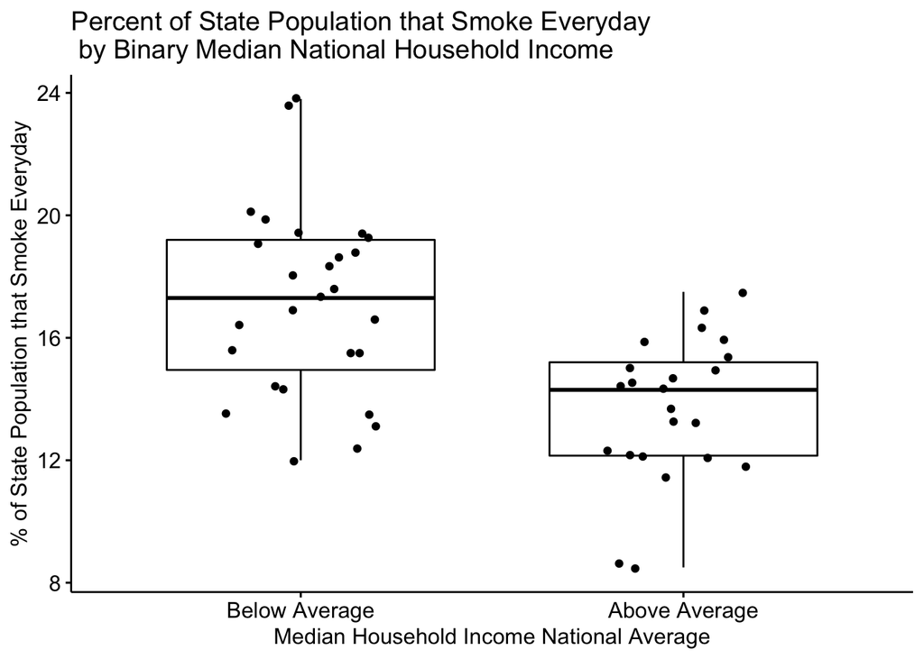

```r
readRDS(file = here::here("output", "finalproject3.rds"))
```

#### % of State Population that Smoke Everyday by Binary Median National Household Income